# RAMYA KARANAM GRADED ASSIGNMENT

## CAPSTONE: Human Resource Management

### Case Study: The Role of Physical Strength in Modern Workplaces

#### Title: Exploring the Impact of Physical Abilities on Job Performance: A Statistical Analysis in Physically Demanding Professions.

```python
import pandas as pd
import numpy as np
import matplotlib.pyplot as plt
import seaborn as sns
import statsmodels.api as sm
import scipy.stats as st
```

```python
## Step 1. DATA EXPLORATION

# Read data

df = pd.read_excel('Case Study_1 dataset.xlsx', sheet_name='Sheet2')

# Display basic information about the dataset
print(df.info())
```

```
<class 'pandas.core.frame.DataFrame'>
RangeIndex: 560 entries, 0 to 559
Data columns (total 4 columns):
 #   Column   Non-Null Count  Dtype
---  ------   --------------  -----
 0   GRIP     560 non-null    float64
 1   ARM      560 non-null    float64
 2   RATINGS  560 non-null    float64
 3   SIMS     560 non-null    float64
dtypes: float64(4)
memory usage: 17.6 KB
None
```

```python
# Display summary statistics
print(df.describe())
```

```
             GRIP         ARM     RATINGS        SIMS
count  560.000000  560.000000  560.000000  560.000000
mean   110.185714   80.030357   40.986082    0.214321
std     20.219577   17.845114    7.806317    2.520152
min     29.000000   19.000000   21.600000   -4.170000
25%     99.000000   69.500000   35.600000   -0.800000
50%    110.000000   82.500000   40.800000    0.030000
75%    121.500000   90.500000   47.125000    0.910000
max    189.000000  132.000000   57.200000   49.000000
```

```python
# Step 2: DATA CLEANING

# Handle missing values
df = df.dropna()
df
```

|  | GRIP | ARM | RATINGS | SIMS |
| --- | --- | --- | --- | --- |
| 0 | 105.5 | 80.5 | 31.8 | 1.18 |
| 1 | 106.5 | 93.0 | 39.8 | 0.94 |
| 2 | 94.0 | 81.0 | 46.8 | 0.84 |
| 3 | 90.5 | 33.5 | 52.2 | -2.45 |
| 4 | 104.0 | 47.5 | 31.2 | 1.00 |
| ... | ... | ... | ... | ... |
| 555 | 113.0 | 87.0 | 49.1 | -0.25 |
| 556 | 133.5 | 96.5 | 44.6 | 2.27 |
| 557 | 89.5 | 63.5 | 37.8 | -0.93 |
| 558 | 95.0 | 70.0 | 35.4 | -0.58 |
| 559 | 90.5 | 33.5 | 52.2 | -2.45 |

560 rows × 4 columns

```python
# Step 3.CORRELATION ANALYSIS

# Pearson Correlation
correlation_matrix = df.corr()
print(correlation_matrix)
```

```
             GRIP       ARM   RATINGS      SIMS
GRIP     1.000000  0.645882  0.184689  0.337920
ARM      0.645882  1.000000  0.203917  0.367320
RATINGS  0.184689  0.203917  1.000000  0.135599
SIMS     0.337920  0.367320  0.135599  1.000000
```

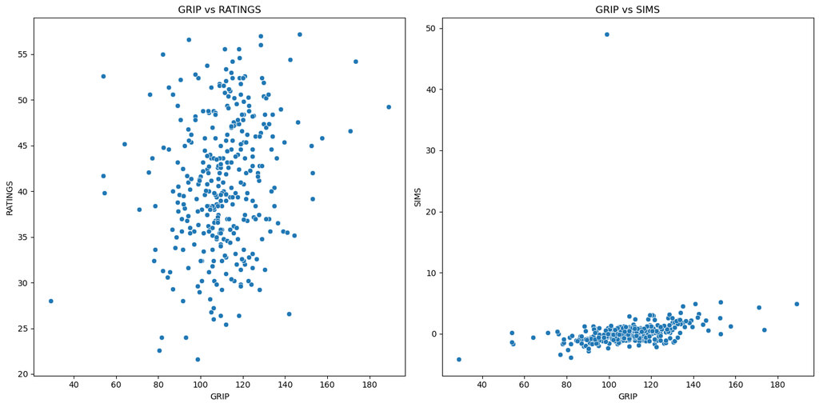

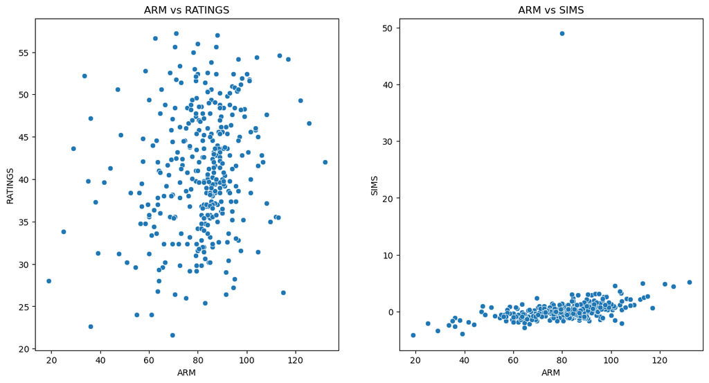

```python
# Step 4: DATA VISUALIZATION

# Scatter plot

plt.figure(figsize=(14, 7))

# Scatter plot for 'GRIP' and 'RATINGS'
plt.subplot(1, 2, 1)
sns.scatterplot(x='GRIP', y='RATINGS', data=df)
plt.title('GRIP vs RATINGS')

# Scatter plot for 'GRIP' and 'SIMS'
plt.subplot(1, 2, 2)
sns.scatterplot(x='GRIP', y='SIMS', data=df)
plt.title('GRIP vs SIMS')

plt.tight_layout()
plt.show()

# Create scatter plots for 'ARM' and 'RATINGS', 'ARM' and 'SIMS'
plt.figure(figsize=(14, 7))

# Scatter plot for 'ARM' and 'RATINGS'
plt.subplot(1, 2, 1)
sns.scatterplot(x='ARM', y='RATINGS', data=df)
plt.title('ARM vs RATINGS')

# Scatter plot for 'ARM' and 'SIMS'
plt.subplot(1, 2, 2)
sns.scatterplot(x='ARM', y='SIMS', data=df)
plt.title('ARM vs SIMS')
```

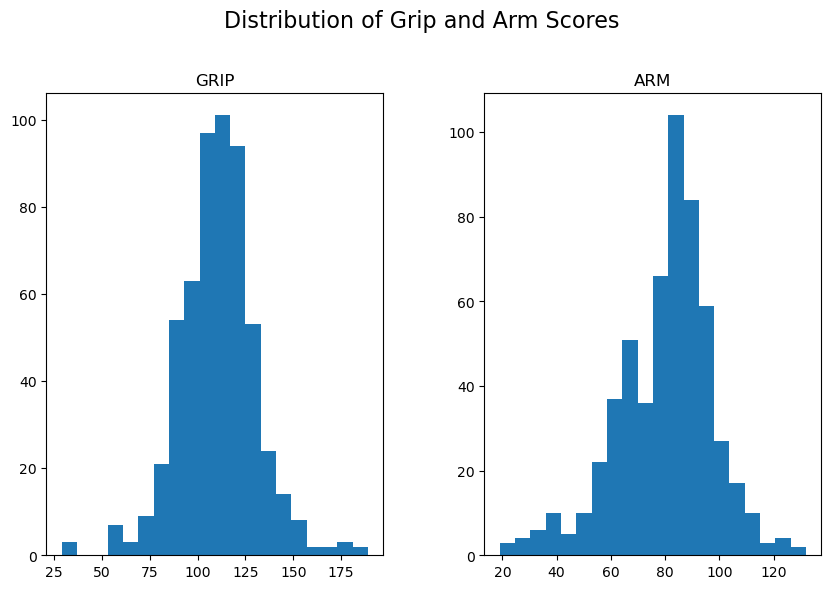

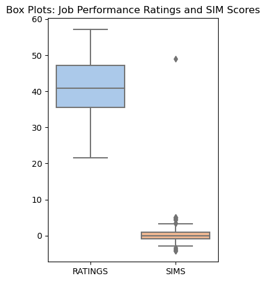

```python
# Histograms for distribution of Grip vs Arm scores

df[['GRIP', 'ARM']].hist(bins=20, figsize=(10, 6), grid=False)
plt.suptitle('Distribution of Grip and Arm Scores', y=1.02, fontsize=16)
plt.show()


# Box Plots for Job Performance Ratings and SIM Scores
plt.subplot(1, 2, 2)
sns.boxplot(data=df[['RATINGS', 'SIMS']], palette='pastel')
plt.title('Box Plots: Job Performance Ratings and SIM Scores')

plt.tight_layout()
plt.show()
```

## Interpretation on Correlation:

[output not shown]

## Stronger positive correlations suggest a more consistent relationship between variables, while weaker correlations indicate less consistency.

### Does physical strength have a measurable impact on job performance in physically demanding professions

### such as construction work,electrical work, and auto mechanics?

### Interpretation:

```
 Grip and arm strength are positively related, meaning individuals with strong grips also tend to have strong arms.

Grip strength shows a moderate positive connection with success in simulated physically demanding tasks (SIM scores). Those with stronger grips often perform better in simulations.

However, the relationship between grip strength and subjective job performance ratings is weak, suggesting that having a strong grip alone may not strongly influence how supervisors rate job performance.

Similarly, while there's a moderate positive connection between arm strength and SIM scores, the correlation between arm strength and job performance ratings is also weak.
```

## Conclusion :

The correlation analysis suggests that while physical strength, especially grip and arm strength, is positively associated with certain aspects of job performance (simulations), the relationship is not extremely strong with subjective job performance ratings.

Other factors beyond physical strength may also play a role in determining job performance ratings.

## HYPOTHESIS TESTING:

```
Hypothesis 1: There is a significant positive correlation between grip strength and simulation scores.
    Test: Pearson correlation test with the null hypothesis:
            H0:ρGRIP,SIMS=0 (no correlation)
            H1: correlation exists

Hypothesis 2: There is a significant positive correlation between arm strength and simulation scores.
    Test: Pearson correlation test with the null hypothesis:
            H0:ρARM, SIMS=0 (no correlation).
            H1: correlation exists

Hypothesis 3: There is a significant positive correlation between supervisor ratings and simulation scores.
    Test: Pearson correlation test with the null hypothesis:
            H0:ρRATINGS, SIMS=0 (no correlation).
            H1: correlation exists
```

```python
from scipy.stats import pearsonr

alpha = 0.05

# Hypothesis 1: Correlation between grip strength and simulation scores
corr_GRIP_SIMS, p_value_GRIP_SIMS = pearsonr(df['GRIP'], df['SIMS'])
print(f"Pearson correlation coefficient (GRIP vs. SIMS): {corr_GRIP_SIMS}, p-value: {p_value_GRIP_SIMS}")

# Hypothesis 2: Correlation between arm strength and simulation scores
corr_ARM_SIMS, p_value_ARM_SIMS = pearsonr(df['ARM'], df['SIMS'])
print(f"Pearson correlation coefficient (ARM vs. SIMS): {corr_ARM_SIMS}, p-value: {p_value_ARM_SIMS}")

# Hypothesis 3: Correlation between supervisor ratings and simulation scores
corr_RATINGS_SIMS, p_value_RATINGS_SIMS = pearsonr(df['RATINGS'], df['SIMS'])
print(f"Pearson correlation coefficient (RATINGS vs. SIMS): {corr_RATINGS_SIMS}, p-value: {p_value_RATINGS_SIMS}")
```

```
Pearson correlation coefficient (GRIP vs. SIMS): 0.3379197841203938, p-value: 2.0037560893919341e-16
Pearson correlation coefficient (ARM vs. SIMS): 0.36732016082636487, p-value: 2.49270598301617e-19
Pearson correlation coefficient (RATINGS vs. SIMS): 0.13559919211415394, p-value: 0.0012973708869139344
```

## Conclusion :

p-value is less than the chosen significance level ( 0.05), so we reject the null hypothesis.

For both grip strength and arm strength, there is strong evidence of a positive correlation with simulation scores.

Supervisor ratings also show a positive correlation with simulation scores, although it is weaker compared to the correlations with physical strength measures.

These results provide statistical evidence supporting the relationships between physical strength measures and simulation scores. The small p-values suggest that these correlations are unlikely to be due to random chance.

## Recommendations:

```
When selecting candidates for physically demanding jobs, considerations beyond physical strength,
such as skills and experience, should also be taken into account.

Simulation tasks may provide a more reliable measure of a candidate's
ability to perform in a physically demanding role compared to subjective ratings alone.
```